# Cure Model Analysis Example

# Introduction

This package allows you to easily build and report cure mixture models. The modeling functions are wrappers for the `smcure()` function from the {smcure} package and several functions are available to diagnose and visualize your cure model results.

# Example data set

We will be using publicly available data on 205 stage I melanoma patients at the Department of Plastic Surgery, University Hospital of Odense, Denmark from 1962 to 1977. The data is available in the {ISwR} package (Dalgaard, 2008).

Variables include: - `ulc` - ulceration status - `thick` - tumor thickness in mm - `sex` - sex

We created categorized version of tumor thickness

```r
df <- ISwR::melanom

mel <- ISwR::melanom %>%
  mutate(status = case_when(status %in% c(1) ~ 1,
                            status %in% c(2, 3) ~ 0)) %>%
  mutate(thick_cat =
              case_when(thick <= 129 ~ "≤ 129",
                        thick <= 322 ~ "less equal 322",
                        thick > 322 ~ "greater 322")) %>%
  mutate(thick_cat = fct_relevel(thick_cat, "≤ 129", "≤ 322")) %>%
  mutate(sex = case_when(sex == 2 ~ "male",
                         sex == 1 ~ "female"),
         ulc = case_when(ulc == 1 ~ "present",
                         ulc == 2 ~ "absent"))
mel %>%
  select(thick_cat, sex, ulc) %>%
  tbl_summary() %>%
  bold_labels()
```

| **Characteristic** | **N = 205**<sup>1</sup> |
| --- | --- |
| thick_cat |  |
| ≤ 129 | 77 (38%) |
| greater 322 | 60 (29%) |
| less equal 322 | 68 (33%) |
| sex |  |
| female | 126 (61%) |
| male | 79 (39%) |
| ulc |  |
| absent | 115 (56%) |
| present | 90 (44%) |

<sup>*1*</sup> Statistics presented: n (%)

To calculate overall survival, we will only consider death from melanoma as an event. Patients who died from other cause or were lost to follow-up are censored.

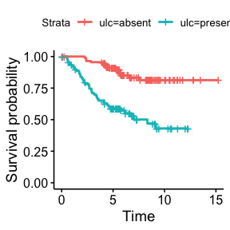

```r
fit <- survfit(Surv(days/365, status) ~ ulc, data = mel)

fit %>% ggsurvplot()
```

# Fitting the Cure Model

The `fit_cure()` function is a wrapper for `smcure::smcure()`. It differs from the original function in that it allows you to pass multi-level categorical variables and also provides necessary model outputs to create calibration curves and calculate k-indicies.

```r
fit <- fit_cure(formula = Surv(days, status) ~ ulc + sex +
                  thick_cat,
                data = mel)
```

```
#> * NA -> ...1
#> * NA -> ...2
#> Warning: Predicate functions must be wrapped in `where()`.
#>
#>   # Bad
#>   data %>% select(is.character)
#>
#>   # Good
#>   data %>% select(where(is.character))
#>
#> ℹ Please update your code.
#> Program is running..be patient... done.
#> Call:
#> smcure(formula = surv_formula, cureform = cure_formula, data = data_for_smcure,
#>     model = "ph", Var = TRUE)
#>
#> Cure probability model:
#>                           Estimate Std.Error    Z value     Pr(>|Z|)
#> (Intercept)             -2.2511417 0.6613157 -3.4040346 0.0006639833
#> ulcpresent               1.2475030 0.5336601  2.3376361 0.0194061356
#> sexmale                  0.2828872 0.3606390  0.7844055 0.4328021966
#> thick_catgreater 322     1.3786136 0.7273956  1.8952735 0.0580561748
#> thick_catless equal 322  1.3417721 0.7491546  1.7910482 0.0732855605
#>
#>
#> Failure time distribution model:
#>                             Estimate Std.Error    Z value   Pr(>|Z|)
#> ulcpresent                -0.1673834 0.4393757 -0.3809574 0.70323486
#> sexmale                    0.4433778 0.4319016  1.0265714 0.30462232
#> `thick_catgreater 322`     1.3693340 0.7552692  1.8130409 0.06982551
#> `thick_catless equal 322`  0.1199237 0.5943261  0.2017809 0.84008799
#> * NA -> ...1
#> * NA -> ...2
```

```r
x <- mmcure(fit$smcure_model_object) %>%
  transmute(variable = str_remove_all(name, fixed("Z[, -1]")),
            value,
            pvalue) %>%
  filter(variable != "(Intercept)")


y <- mmsurv(fit$smcure_model_object) %>%
  transmute(variable = str_remove_all(
    str_remove_all(name, fixed("X[, -1]")), fixed("`")),
            value,
            pvalue)

all <- x %>% left_join(y, by = "variable", suffix = c("_cure", "_survival"))
all %>%
  gt()
```

| variable | value_cure | pvalue_cure | value_survival | pvalue_survival |
| --- | --- | --- | --- | --- |
| ulcpresent | 3.48 | 0.02 | 0.85 | 0.70 |
| sexmale | 1.33 | 0.43 | 1.56 | 0.30 |
| thick_catgreater 322 | 3.97 | 0.06 | 3.93 | 0.07 |
| thick_catless equal 322 | 3.83 | 0.07 | 1.13 | 0.84 |

# K-Index

Below we calculate the K and C indicies for this model

```r
library(ROCR)

mod_data <- mel %>%
  mutate(sex = as.integer(as.factor(sex))-1)

mm <- model.matrix(~ulc + sex +
                  thick_cat, data = mod_data)[, -1]

mod2 <- mod_data %>%
  dplyr::select(days, status) %>%
  cbind(mm)

k_fit <- evacure::smcure1(Surv(days, status) ~ ulcpresent +
                            sex +
                            `thick_catgreater 322` +
                            `thick_catless equal 322`,
      cureform = ~ ulcpresent +
                            sex +
                            `thick_catgreater 322` +
                            `thick_catless equal 322`,
      data = mod2,
      model = "ph",
      nboot = 200,
      Var = T
      )
```

```
#> Program is running..be patient...
#>
#> Warning in fitter(X, Y, istrat, offset, init, control, weights = weights, :
#> Loglik converged before variable 3 ; coefficient may be infinite.
#>  done.
```

```r
k_index <- k_fit$eva["K"]
c_index <- k_fit$eva["C"]


tribble(
  ~"Statistic", ~"Value",
  "k-index", k_index,
  "c-index", c_index) %>%
  mutate_if(is.numeric, ~round(.x, 3)) %>%
  gt() %>%
  gt::tab_options(table.font.size = "small",
        data_row.padding = gt::px(1),
        summary_row.padding = gt::px(1),
        grand_summary_row.padding = gt::px(1),
        footnotes.padding = gt::px(1),
        source_notes.padding = gt::px(1),
        row_group.padding = gt::px(1))
```

| Statistic | Value |
| --- | --- |
| k-index | 0.748 |
| c-index | 0.704 |

# Calibration Curve

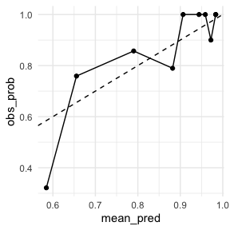

```r
cure_calibration(fit, prediction_time = 1000)
```